# Lesson_1

Библиотека **Matplotlib** является одним из самых популярных средств визуализации данных на Python. Она отлично подходит как для создания статичных изображений, так и анимированных, и интерактивных решений.

**Урок 1** посвящен знакомству с библиотекой matplotlib. Здесь изложены основы по созданию графики.

**Pyplot** — это модуль в пакете **Matplotlib**. Его вы часто будете видеть в коде как **matplotlib.pyplot**. Модуль помогает автоматически создавать оси, фигуры и другие компоненты, не задумываясь о том, как это происходит. Именно Pyplot используется в большинстве случаев.

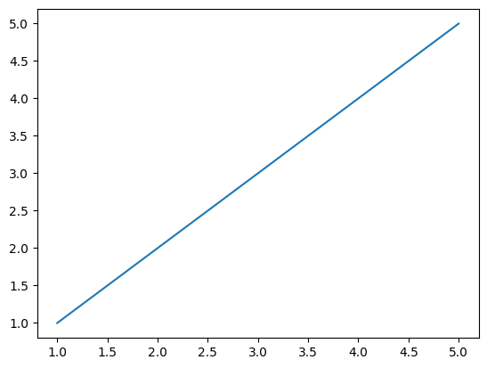

```python
# Импортируем matplotlib и рисуемсамый простой линейный график

import matplotlib.pyplot as plt
plt.plot([1, 2, 3, 4, 5], [1, 2, 3, 4, 5])
plt.show()
```

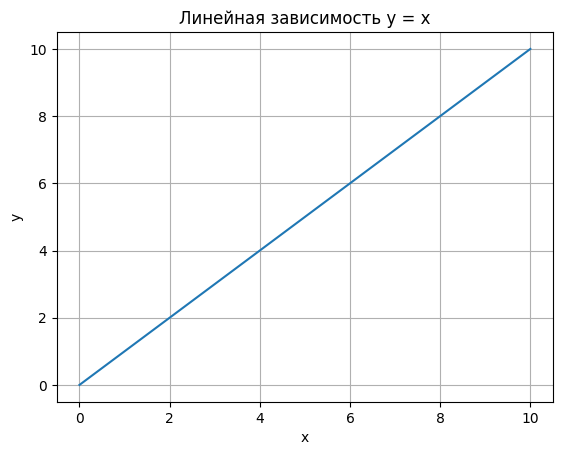

```python
import numpy as np # Библиотека для работы с многомерными массивами,

# Независимая (x) и зависимая (y) переменные
# Cоздадим массив из заданного количества вещественных равномерно распределённых значений (50) из указанного диапазона [0,10].
x = np.linspace(0, 10, 50)
y = x

# Построение графика
plt.title('Линейная зависимость y = x') # заголовок
plt.xlabel('x') # ось абсцисс
plt.ylabel('y') # ось ординат
plt.grid() # включение отображения сетки
plt.plot(x, y) # построение графика
```

Изменим тип линии и её цвет, для этого в функцию **plot()**, в качестве третьего параметра, передадим строку, сформированную определенным образом, в нашем случае это '**r--**', где '**r**' означает красный цвет, а '**--**' – тип линии – пунктирная линия:

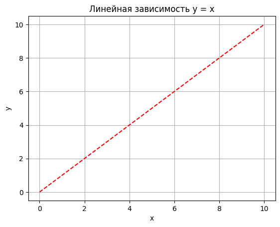

```python
# Построение графика
plt.title('Линейная зависимость y = x') # заголовок
plt.xlabel('x') # ось абсцисс
plt.ylabel('y') # ось ординат
plt.grid() # включение отображения сетки
plt.plot(x, y, 'r--') # построение графика
```

Построим несколько графиков на одном поле, для этого добавим квадратичную зависимость:

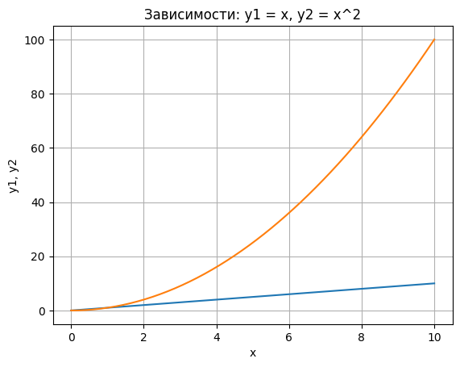

```python
# Линейная зависимость
x = np.linspace(0, 10, 50)
y1 = x

# Квадратичная зависимость
y2 = [i**2 for i in x]

# Построение графика
plt.title('Зависимости: y1 = x, y2 = x^2') # заголовок
plt.xlabel('x') # ось абсцисс
plt.ylabel('y1, y2') # ось ординат
plt.grid() # включение отображения сетки
plt.plot(x, y1, x, y2) # построение графика
```

Построим уже известные нам зависимости на разных полях:

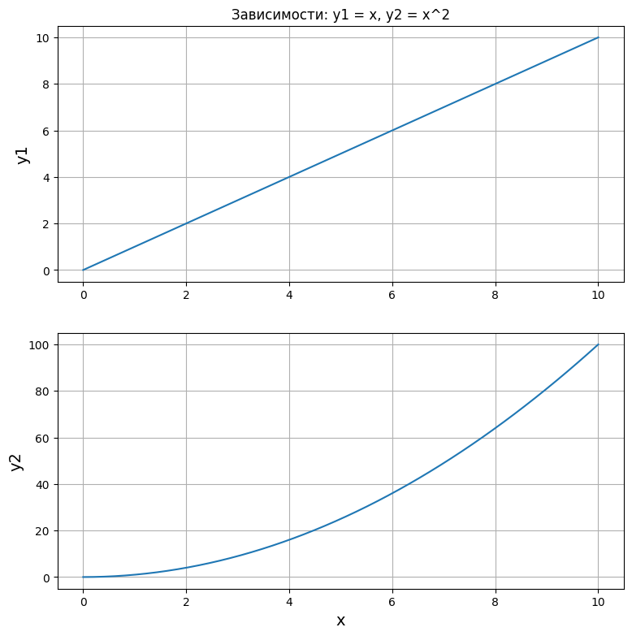

```python
x = np.linspace(0, 10, 50)
y1 = x # Линейная зависимость
y2 = [i**2 for i in x] # Квадратичная зависимость

# Построение графиков
# Самым главным объектом в matplotlib является рисунок Figure (метод plt.figure()).
# Создать рисунок в matplotlib означает задать форму, размеры и свойства основы-холста (canvas), на котором будет создаваться будущий график.
plt.figure(figsize=(9, 9))
plt.subplot(2, 1, 1) # количество строк, столбцов в формируемом поле, индекс (номер поля, считаем сверху вниз, слева направо).
plt.plot(x, y1) # построение графика
plt.title('Зависимости: y1 = x, y2 = x^2') # заголовок
plt.ylabel('y1', fontsize=14) # ось ординат
plt.grid(True) # включение отображение сетки

plt.subplot(2, 1, 2)
plt.plot(x, y2) # построение графика
plt.xlabel('x', fontsize=14) # ось абсцисс
plt.ylabel('y2', fontsize=14) # ось ординат
plt.grid(True) # включение отображение сетки
```

Здесь мы воспользовались двумя новыми функциями:

• **figure()** – функция для задания глобальных параметров отображения графиков. В неё через параметр figsize передаётся кортеж из двух элементов, определяющий общий размер фигуры.

• **subplot()** – функция для задания местоположения поля с графиком. Существует несколько способов задания областей для вывода графиков.

В примере мы воспользовались вариантом, который предполагает передачу **трёх аргументов**: первый аргумент – **количество строк**, второй – **столбцов** в формируемом поле, третий – **индекс** (номер поля, считаем сверху вниз, слева направо).

Остальные функции вам знакомы, дополнительно мы использовали параметр fontsize функций xlabel() и ylabel() для задания размера шрифта

Неудобство использования последовательного вызова функций **subplot()** заключается в том, что каждый раз приходится указывать количество строк и столбцов сетки. Для того, чтобы этого избежать, можно воспользоваться функцией **subplots()**, из всех ее параметров нас интересуют только первые два, через них передаётся **количество строк** и **столбцов** сетки.

Функция **subplots()** возвращает два объекта, первый – это **Figure**, подложка, на которой будут размещены поля с графиками, второй – **объект** (или массив объектов) **Axes**, через который можно получить полный доступ к настройке внешнего вида отображаемых элементов.

Решим задачу вывода четырёх графиков с помощью **subplots()**:

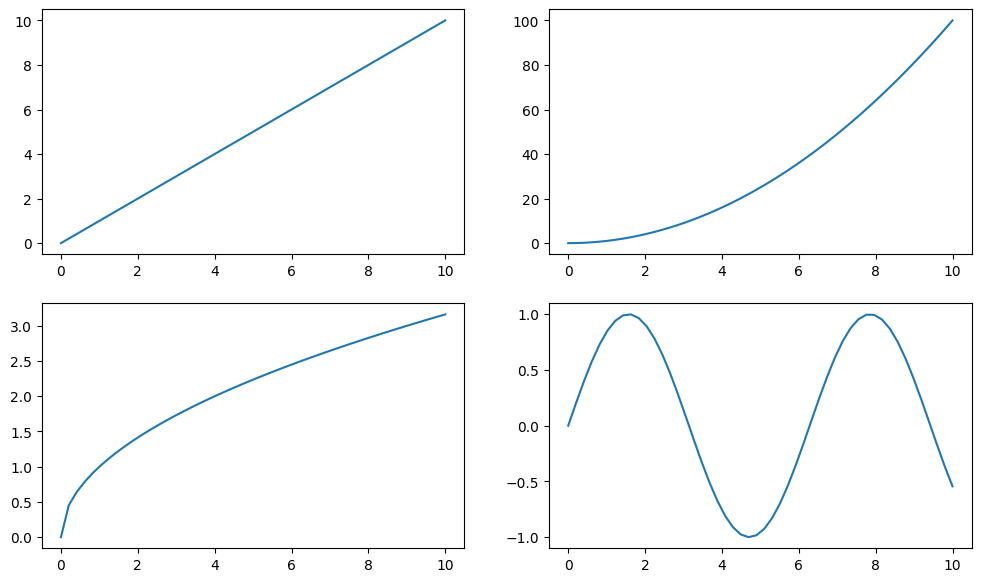

```python
import math # для вычисления синуса

x = np.linspace(0, 10, 50)
y1 = x # Линейная зависимость
y2 = [i**2 for i in x] # Квадратичная зависимость
y3 = [i**(1/2) for i in x] # Квадратный корень
y4 = [math.sin(i) for i in x] # Синус

# Построение графика
fig, axs = plt.subplots(
    2,                      # две строки
    2,                      # два стролбца
    figsize=(12, 7))        # вписать в размер 12х7 дюймов
axs[0, 0].plot(x, y1)       # первый график сетки
axs[0, 1].plot(x, y2)
axs[1, 0].plot(x, y3)
axs[1, 1].plot(x, y4);
```

Класс **GridSpec** позволяет задавать геометрию сетки и расположение на ней полей с графиками. Может показаться, что работа с **GridSpec** довольно неудобна и требует написания лишнего кода, но, если требуется расположить поля с графиками нетривиальным способом, то этот инструмент становится незаменимым.

Для начала решим простую задачу отображения двух полей с графиками с использованием **GridSpec**:

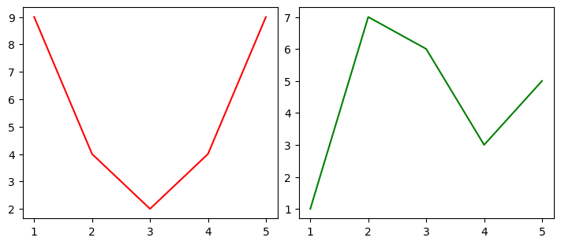

```python
# Импортируем GridSpec:
import matplotlib.gridspec as gridspec

# Зададим данные для графиков:
x = [1, 2, 3, 4, 5]
y1 = [9, 4, 2, 4, 9]
y2 = [1, 7, 6, 3, 5]

# Создаем "заготовку" для наших будущих графиков
fg = plt.figure(figsize=(7, 3), constrained_layout=True)
# constrained_layout автоматически настраивает подграфики так, чтобы такие элементы декора, как метки, легенды и цветные полосы,
# не перекрывались, сохраняя при этом логический макет, запрошенный пользователем.

# Создаем макет сетки для размещения подграфиков внутри фигуры.
gs = gridspec.GridSpec(ncols=2, nrows=1, figure=fg)

fig_ax_1 = fg.add_subplot(gs[0, 0]) # Первый график
plt.plot(x, y1, color = 'red')
fig_ax_2 = fg.add_subplot(gs[0, 1]) # Второй график
plt.plot(x, y2, color = 'green');
```

Добавим еще один график:

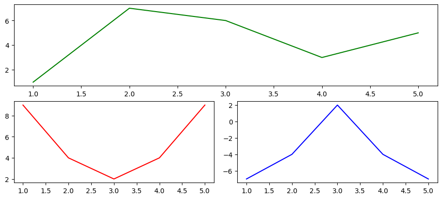

```python
x = [1, 2, 3, 4, 5]
y1 = [9, 4, 2, 4, 9]
y2 = [1, 7, 6, 3, 5]
y3 = [-7, -4, 2, -4, -7]

# Построим графики в новой компоновке:
fg = plt.figure(figsize=(9, 4), constrained_layout=True)

gs = fg.add_gridspec(2, 2)
# Конструкция [0, :] говорит о том, что первый график начинается с ячейки 0 и до конца текущей строки;
# [1, 0] - ячейка с номером 0 в 1-й строке и т.д.
fig_ax_1 = fg.add_subplot(gs[0, :])
plt.plot(x, y2, color = 'green')
fig_ax_2 = fg.add_subplot(gs[1, 0])
plt.plot(x, y1, color = 'red')
fig_ax_3 = fg.add_subplot(gs[1, 1])
plt.plot(x, y3, color = 'blue');
```

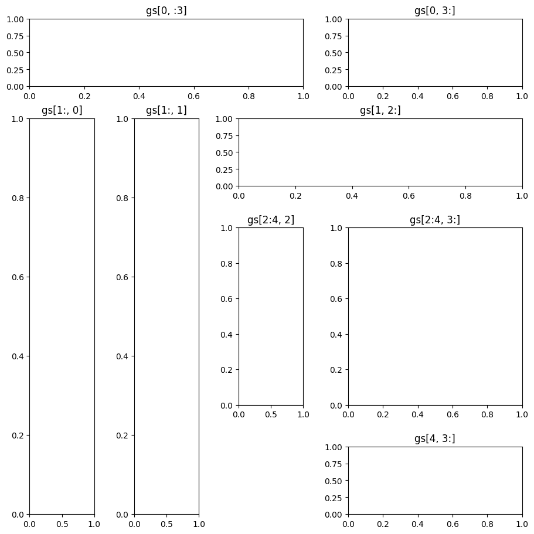

```python
# Ниже представлен ещё один пример без данных (с пустыми полями), который иллюстрирует возможности GridSpec:
fg = plt.figure(figsize=(9, 9), constrained_layout=True)
gs = fg.add_gridspec(5, 5)
fig_ax_1 = fg.add_subplot(gs[0, :3])
fig_ax_1.set_title('gs[0, :3]')
fig_ax_2 = fg.add_subplot(gs[0, 3:])
fig_ax_2.set_title('gs[0, 3:]')
fig_ax_3 = fg.add_subplot(gs[1:, 0])
fig_ax_3.set_title('gs[1:, 0]')
fig_ax_4 = fg.add_subplot(gs[1:, 1])
fig_ax_4.set_title('gs[1:, 1]')
fig_ax_5 = fg.add_subplot(gs[1, 2:])
fig_ax_5.set_title('gs[1, 2:]')
fig_ax_6 = fg.add_subplot(gs[2:4, 2])
fig_ax_6.set_title('gs[2:4, 2]')
fig_ax_7 = fg.add_subplot(gs[2:4, 3:])
fig_ax_7.set_title('gs[2:4, 3:]')
fig_ax_8 = fg.add_subplot(gs[4, 3:])
fig_ax_8.set_title('gs[4, 3:]');
```

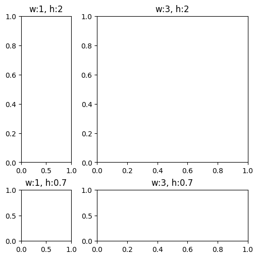

```python
# Можно заранее задать размеры областей и передать их в качестве параметров в виде массивов:
fg = plt.figure(figsize=(5, 5),constrained_layout=True)
widths = [1, 3]
heights = [2, 0.7]
gs = fg.add_gridspec(ncols=2, nrows=2, width_ratios=widths, height_ratios=heights)
fig_ax_1 = fg.add_subplot(gs[0, 0])
fig_ax_1.set_title('w:1, h:2')
fig_ax_2 = fg.add_subplot(gs[0, 1])
fig_ax_2.set_title('w:3, h:2')
fig_ax_3 = fg.add_subplot(gs[1, 0])
fig_ax_3.set_title('w:1, h:0.7')
fig_ax_4 = fg.add_subplot(gs[1, 1])
fig_ax_4.set_title('w:3, h:0.7');
```

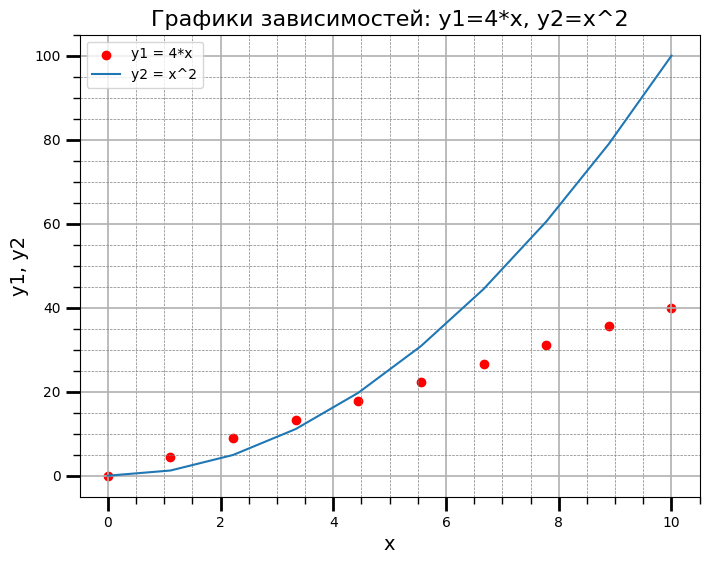

```python
# Пример графика мо всеми элементами

# Модуль matplotlib.ticker содержит несколько локаторов, использующие различные алгоритмы расположения рисок.
from matplotlib.ticker import (MultipleLocator, FormatStrFormatter, AutoMinorLocator)

x = np.linspace(0, 10, 10)
y1 = 4*x
y2 = [i**2 for i in x]
fig, ax = plt.subplots(figsize=(8, 6))

ax.set_title('Графики зависимостей: y1=4*x, y2=x^2', fontsize=16)
ax.set_xlabel('x', fontsize=14)
ax.set_ylabel('y1, y2', fontsize=14)
ax.grid(which='major', linewidth=1.2)
ax.grid(which='minor', linestyle='--', color='gray', linewidth=0.5)
ax.scatter(x, y1, c='red', label='y1 = 4*x')
ax.plot(x, y2, label='y2 = x^2')
ax.legend()

ax.xaxis.set_minor_locator(AutoMinorLocator())
ax.yaxis.set_minor_locator(AutoMinorLocator())
ax.tick_params(which='major', length=10, width=2)
ax.tick_params(which='minor', length=5, width=1)
plt.show()
```